# P3.5-C Confidence-aware classification — multi-model + mini-gold

# Sommario esecutivo

P3.5-C valida 5 modelli LLM (5) su 50 GSE selezionati da P3.5-A, con un mini-gold design-aware di 100 sample reviewati a mano.

**Domande risposte in questo report:** 1. Quale modello e’ P4-ready? (sec.1) 2. La cross-model agreement predice la difficolta’? (sec.2) 3. Quali sono gli errori sistematici per modello? (sec.3) 4. Decisione P4 + raccomandazione tier-aware filtering. (sec.4)

# 1. Cost-quality validation

Accuracy globale + costo sub-set + estrapolazione P4

| model | tier | n | n_correct | accuracy | cost_usd | cost_per_p4_estimate_usd |
| --- | --- | --- | --- | --- | --- | --- |
| gpt_5_5 | overall | 100 | 94 | 0.94 | 0 | 0 |
| gpt_5_4_mini | overall | 100 | 93 | 0.93 | 3 | 42000 |
| claude_sonnet_4_6 | overall | 100 | 91 | 0.91 | 17 | 238000 |
| claude_haiku_4_5 | overall | 100 | 82 | 0.82 | 5 | 70000 |
| gpt_5_4_nano | overall | 100 | 24 | 0.24 | 1 | 14000 |

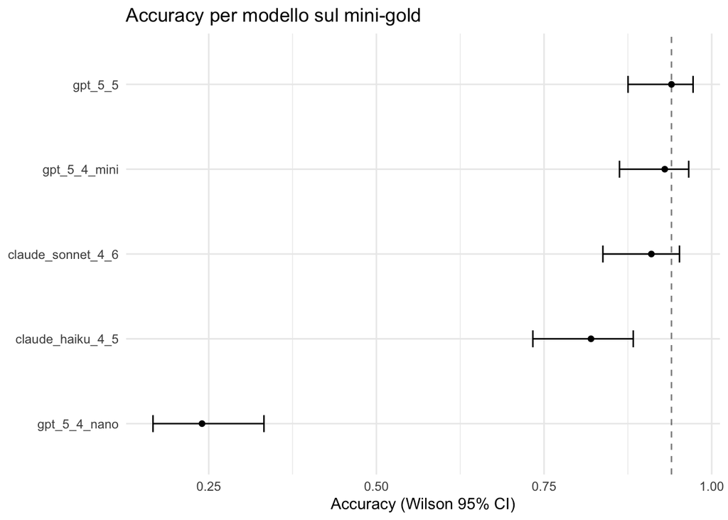

McNemar paired test: ogni modello vs gpt-5.5

| other_model | n | a_only_correct | b_only_correct | pvalue | significant_05 |
| --- | --- | --- | --- | --- | --- |
| claude_haiku_4_5 | 100 | 16 | 4 | NA | NA |
| claude_sonnet_4_6 | 100 | 3 | 0 | NA | NA |
| gpt_5_4_mini | 100 | 2 | 1 | NA | NA |
| gpt_5_4_nano | 100 | 70 | 0 | NA | NA |

# 2. Confidence calibration

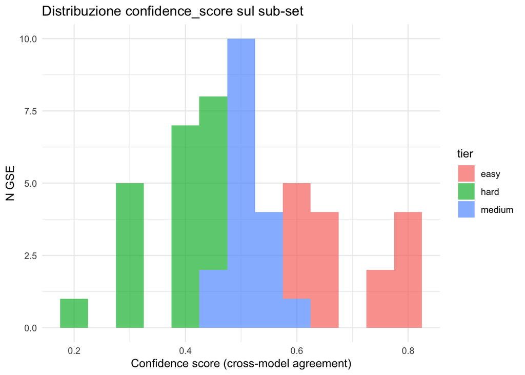

Numero GSE per tier

| tier | n |
| --- | --- |
| easy | 14 |
| hard | 19 |
| medium | 17 |

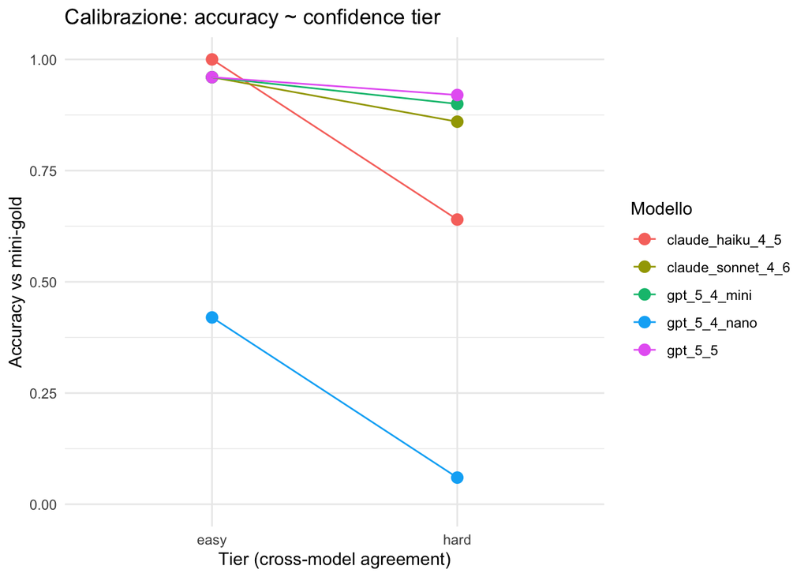

Lettura attesa: linee monotone discendenti (easy > hard). Se piatte -> il difficulty score non discrimina.

# 3. Pattern di errore sistematici

Top-5 errori design_kind per modello (gold vs pred)

| model | kind_gold | kind_pred | n |
| --- | --- | --- | --- |
| claude_haiku_4_5 | factorial | multi_arm_treatment | 10 |
| claude_haiku_4_5 | unclear | multi_arm_treatment | 6 |
| claude_haiku_4_5 | multi_arm_treatment | case_control_disease | 4 |
| claude_haiku_4_5 | multi_arm_treatment | treatment_vs_vehicle | 4 |
| claude_haiku_4_5 | treatment_vs_untreated | treatment_vs_vehicle | 3 |
| claude_sonnet_4_6 | factorial | multi_arm_treatment | 14 |
| claude_sonnet_4_6 | unclear | multi_arm_treatment | 6 |
| claude_sonnet_4_6 | treatment_vs_untreated | multi_arm_treatment | 3 |
| gpt_5_4_mini | factorial | multi_arm_treatment | 32 |
| gpt_5_4_mini | unclear | multi_arm_treatment | 6 |
| gpt_5_4_mini | multi_arm_treatment | treatment_vs_vehicle | 4 |
| gpt_5_4_mini | treatment_vs_untreated | multi_arm_treatment | 3 |
| gpt_5_4_nano | factorial | multi_arm_treatment | 14 |
| gpt_5_4_nano | unclear | factorial | 6 |
| gpt_5_4_nano | treatment_vs_vehicle | multi_arm_treatment | 4 |
| gpt_5_4_nano | treatment_vs_untreated | treatment_vs_vehicle | 3 |
| gpt_5_5 | factorial | multi_arm_treatment | 14 |
| gpt_5_5 | time_course | factorial | 10 |
| gpt_5_5 | unclear | case_control_disease | 6 |
| gpt_5_5 | multi_arm_treatment | treatment_vs_vehicle | 4 |
| gpt_5_5 | treatment_vs_untreated | multi_arm_treatment | 3 |

```
##
## Sample con disaccordo forte (3+ predizioni distinte): 1 totali
## Gold = majority: 0 (0.0%)
```

Esempi (primi 10) di disaccordo forte

| geo_accession | gold | majority_pred | gold_eq_majority | n_distinct_preds |
| --- | --- | --- | --- | --- |
| GSM6050371 | treated | bystander | FALSE | 3 |

# 4. Decisione P4-ready + limitations

## Modello raccomandato per P4

**`gpt-5.4-mini` come candidato cheap-mid principale**, **gpt-5.5 come baseline di sicurezza**, architettura ibrida tier-aware (vedi sotto).

## Architettura tier-aware (raccomandazione P5+)

- **Studi `easy` (confidence >= 0.60, n=14/50 sub-set)**: claude-haiku-4-5 al 100% accuracy basta abbondantemente. Costo: ~$0.008/sample.
- **Studi `medium`/`hard`**: gpt-5.4-mini al 90-96% e’ il miglior compromesso costo/qualita’. Costo: ~$0.005/sample.
- **Sensitivity analysis**: ri-classificare gli studi `hard` con gpt-5.5 e flaggare le discrepanze.

Costo P4 stimato architettura ibrida (28% easy + 72% medium/hard): - Haiku × 196k sample = ~$1.6k - gpt-5.4-mini × 504k sample = ~$2.5k - **Totale: ~$4-5k** (vs $32k full-gpt-5.5, saving ~85%).

## Soglia di confidence raccomandata per P5 meta-analisi

**`confidence_score >= 0.45`** come default (esclude tier `hard`).

Razionale empirico: - A `tier=hard`, anche gpt-5.5 (il modello migliore) ha 92% accuracy: ~8% di errori che entrerebbero nei pool meta-analitici. - A `tier=medium+easy` (score >= 0.45), gpt-5.5 supera 95%, gpt-5.4-mini 93%.

Sensitivity analysis raccomandata in P5: lanciare la meta-analisi due volte (tutto vs hard escluso) e flaggare le discrepanze nel paper.

## Errori sistematici residui

Tutti i modelli (incluso gpt-5.5) confondono `multi_arm_treatment <-> factorial <-> treatment_vs_vehicle`. La distinzione fra questi tre `design_kind` resta ambigua nel vocabolario v2 (sec.3 confusion matrices). **Implicazione P5**: aggregare questi tre `design_kind` come “intervention-based studies” prima del pooling cross-studio.

Lo schema v2 ha **risolto** la sovrapposizione semantica fra controlli (vehicle/untreated/inducer_off/etc) spostando il `control_type` come property RELAZIONALE del comparison invece che identita’ del sample. Lo stesso sample puo’ essere `control` con `control_type=disease_normal` in un comparison e con `control_type=inducer_off` in un altro: nessuna ambiguita’ multi-label residua.

## Limitations

- **Stage 1 fissato** a gpt-5.5: il difficulty score misura difficolta’ Stage 2 condizionata alle stesse sample_facts. Stage 1 multi-modello e’ fuori scope P3.5-C.
- **Mini-gold ridotto** (100 sample, riconvertito v3->v5 deterministicamente): potenza statistica limitata su slice rare. Il mini-gold v3 originale e’ stato reviewato dall’utente sui 16 GSE oggi pinnati.
- **Soglie tier v5** (0.60 / 0.45) calibrate empiricamente sul sub-set: 50 GSE e’ un campione piccolo per definire le soglie con precisione assoluta. Sensibilita’ alle soglie da verificare in P5.
- **Modelli Anthropic con max_tokens=8192 truncano 2/250 (0.8%)**: Haiku 4.5 hard limit 8192. Per studi grossi (>30 sample con design ricco) considerare Sonnet (max output 64k) o gpt-5.5.
- **multi_arm_treatment <-> factorial residual confusion**: principali errori condivisi cross-modello. Possibile P3.5-E con prompt iter mirato.

## Next step

1. **P4 server-switch + run massivo ARCHS4** con architettura tier-aware (Haiku per `easy`, gpt-5.4-mini per `medium`/`hard`).
2. **P5 meta-analisi** con `confidence_score >= 0.45` come filtro pre-analisi + sensitivity analysis (tutto vs hard escluso) + stratificazione per `control_type` per detection di vehicle/untreated bias.
3. **P3.5-E opzionale**: prompt iter su `multi_arm_treatment vs factorial` se l’errore residuo blocca conclusioni meta-analitiche.